# Reglas de Asociación

Jorge Ayuso

Mayo 2022

### El carrito de la compra

El “carrito de la compra” se conoce como un ejemplo típico de **reglas de asociación**.

Las [Reglas de asociación](https://en.wikipedia.org/wiki/Association_rule_learning) se utilizan para encontrar patrones habituales en ciertos datos. Por ejemplo qué tipos de productos se suelen comprar juntos:

- Si compra $A$ suele comprar $B$ ($A\to B$).
- El que suele comprar $A$ y $C$ suele comprar $D$ ($\{A,C\}\to D$).
- …

Esta técnica es usada en los lineales del supermercado para saber qué tipo de productos poner juntos, por ejemplo los frutos secos cerca de las bebidas.

Queremos que las reglas que encontremos sean significativas, para ello se suele utilizar como medida el **soporte** y la **confianza**:

$${\large
\begin{eqnarray*}
supp(A) &=& \frac{|A|}{|D|} \\[1.5em]
conf(A\to B) &=& \frac{supp(A \cup B)}{supp(A)}
\end{eqnarray*}
}$$

Donde $D$ es el número total de transacciones.

De manera intuitiva, el soporte es la proporción de veces que aparece el conjunto $A$ en el total de transacciones. Y la confianza es la proporción de veces que aparece $A$ y $B$ cuando aparece $A$.

Con R usaremos el paquete `arules` para realizar este tipo de recomendaciones.

Introducimos un ejemplo sencillo (para más detalle consultar http://www.salemmarafi.com/code/market-basket-analysis-with-r/):

```r
library(arules)
library(arulesViz)
library(datasets)

data(Groceries)
help("Groceries")
```

Vamos a usar los datos de `Groceries`, estos datos contiene las transacciones reales de un supermercado durante un mes

```r
Groceries
```

```
## transactions in sparse format with
##  9835 transactions (rows) and
##  169 items (columns)
```

```r
class(Groceries)
```

```
## [1] "transactions"
## attr(,"package")
## [1] "arules"
```

```r
str(Groceries)
```

```
## Formal class 'transactions' [package "arules"] with 3 slots
##   ..@ data       :Formal class 'ngCMatrix' [package "Matrix"] with 5 slots
##   .. .. ..@ i       : int [1:43367] 13 60 69 78 14 29 98 24 15 29 ...
##   .. .. ..@ p       : int [1:9836] 0 4 7 8 12 16 21 22 27 28 ...
##   .. .. ..@ Dim     : int [1:2] 169 9835
##   .. .. ..@ Dimnames:List of 2
##   .. .. .. ..$ : NULL
##   .. .. .. ..$ : NULL
##   .. .. ..@ factors : list()
##   ..@ itemInfo   :'data.frame':  169 obs. of  3 variables:
##   .. ..$ labels: chr [1:169] "frankfurter" "sausage" "liver loaf" "ham" ...
##   .. ..$ level2: Factor w/ 55 levels "baby food","bags",..: 44 44 44 44 44 44 44 42 42 41 ...
##   .. ..$ level1: Factor w/ 10 levels "canned food",..: 6 6 6 6 6 6 6 6 6 6 ...
##   ..@ itemsetInfo:'data.frame':  0 obs. of  0 variables
```

Los datos están en un objeto de tipo `transactions`. Dentro de este objeto hay una matriz con las transacciones:

```r
Groceries@data[1:10,1:20]
```

```
## 10 x 20 sparse Matrix of class "ngCMatrix"
##
##  [1,] . . . . . . . . . . . . . | . . . . . .
##  [2,] . . . . . . . . . . . . . . . . . . . .
##  [3,] . . . . . . . . . . . . . . . . . . . .
##  [4,] . . . . . . . . . . . . . . . . . . . .
##  [5,] . . . . . . . . . . . . . . . . . . . .
##  [6,] . . . . . . . . . . . . . . . . . . . .
##  [7,] . . . . . . . . . . . . . . . . . . . .
##  [8,] . . . . . . . . . . . . . . | . . . . .
##  [9,] . . . . . . . . . . . . . . . . . . . .
## [10,] . . . . . . . . . . . . . . . . . . . .
```

El paquete `arules` nos proporciona algunas funciones para explorar los datos:

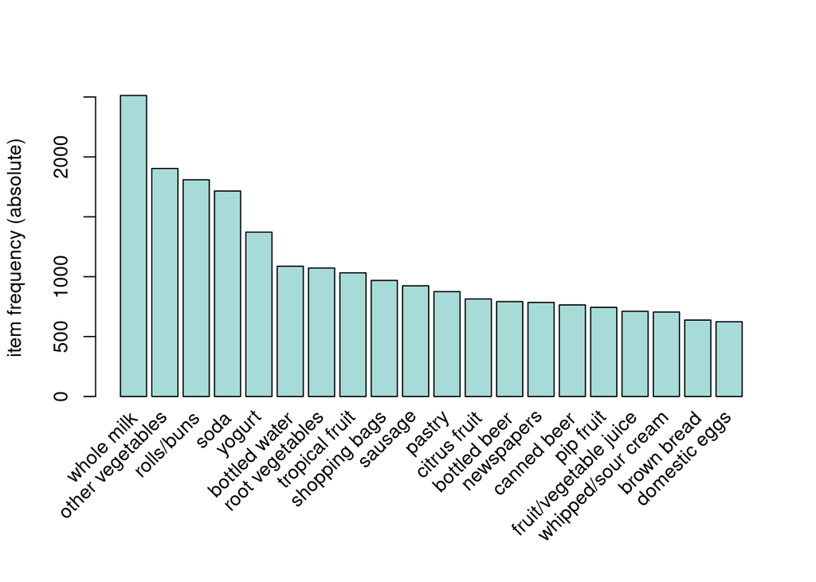

```r
itemFrequencyPlot(Groceries,topN = 20,type = "absolute",col = "#A7DBD8")
```

Usamos la función `apriori` para calcular las reglas. Normalmente se fija a mano el soporte y la confianza que queremos, para ello se suele ser exigentes (para conseguir pocas reglas) y poco a poco relajamos las condiciones hasta conseguir un número adecuado de reglas en función de nuestros propósitos.

```r
rules <- apriori(Groceries, parameter = list(supp = 0.001, conf = 0.8))
```

```
## Apriori
##
## Parameter specification:
##  confidence minval smax arem  aval originalSupport maxtime support minlen
##         0.8    0.1    1 none FALSE            TRUE       5   0.001      1
##  maxlen target  ext
##      10  rules TRUE
##
## Algorithmic control:
##  filter tree heap memopt load sort verbose
##     0.1 TRUE TRUE  FALSE TRUE    2    TRUE
##
## Absolute minimum support count: 9
##
## set item appearances ...[0 item(s)] done [0.00s].
## set transactions ...[169 item(s), 9835 transaction(s)] done [0.00s].
## sorting and recoding items ... [157 item(s)] done [0.00s].
## creating transaction tree ... done [0.00s].
## checking subsets of size 1 2 3 4 5 6 done [0.01s].
## writing ... [410 rule(s)] done [0.00s].
## creating S4 object  ... done [0.00s].
```

```r
rules
```

```
## set of 410 rules
```

Para ver las 5 primeras reglas:

```r
inspect(rules[1:5])
```

```
##     lhs                         rhs            support     confidence
## [1] {liquor, red/blush wine} => {bottled beer} 0.001931876 0.9047619
## [2] {curd, cereals}          => {whole milk}   0.001016777 0.9090909
## [3] {yogurt, cereals}        => {whole milk}   0.001728521 0.8095238
## [4] {butter, jam}            => {whole milk}   0.001016777 0.8333333
## [5] {soups, bottled beer}    => {whole milk}   0.001118454 0.9166667
##     coverage    lift      count
## [1] 0.002135231 11.235269 19
## [2] 0.001118454  3.557863 10
## [3] 0.002135231  3.168192 17
## [4] 0.001220132  3.261374 10
## [5] 0.001220132  3.587512 11
```

También podemos hacer un resumen del objeto:

```r
summary(rules)
```

```
## set of 410 rules
##
## rule length distribution (lhs + rhs):sizes
##   3   4   5   6
##  29 229 140  12
##
##    Min. 1st Qu.  Median    Mean 3rd Qu.    Max.
##   3.000   4.000   4.000   4.329   5.000   6.000
##
## summary of quality measures:
##     support           confidence        coverage             lift
##  Min.   :0.001017   Min.   :0.8000   Min.   :0.001017   Min.   : 3.131
##  1st Qu.:0.001017   1st Qu.:0.8333   1st Qu.:0.001220   1st Qu.: 3.312
##  Median :0.001220   Median :0.8462   Median :0.001322   Median : 3.588
##  Mean   :0.001247   Mean   :0.8663   Mean   :0.001449   Mean   : 3.951
##  3rd Qu.:0.001322   3rd Qu.:0.9091   3rd Qu.:0.001627   3rd Qu.: 4.341
##  Max.   :0.003152   Max.   :1.0000   Max.   :0.003559   Max.   :11.235
##      count
##  Min.   :10.00
##  1st Qu.:10.00
##  Median :12.00
##  Mean   :12.27
##  3rd Qu.:13.00
##  Max.   :31.00
##
## mining info:
##       data ntransactions support confidence
##  Groceries          9835   0.001        0.8
##                                                                   call
##  apriori(data = Groceries, parameter = list(supp = 0.001, conf = 0.8))
```

Podemos realizar muchas más cosas con la función `apriori`, alguna de ellas

```r
rules <- apriori(
                data = Groceries, parameter = list(supp = 0.001,conf = 0.15,minlen = 2),
                appearance = list(default = "rhs",lhs = "whole milk")
               )
```

```
## Apriori
##
## Parameter specification:
##  confidence minval smax arem  aval originalSupport maxtime support minlen
##        0.15    0.1    1 none FALSE            TRUE       5   0.001      2
##  maxlen target  ext
##      10  rules TRUE
##
## Algorithmic control:
##  filter tree heap memopt load sort verbose
##     0.1 TRUE TRUE  FALSE TRUE    2    TRUE
##
## Absolute minimum support count: 9
##
## set item appearances ...[1 item(s)] done [0.00s].
## set transactions ...[169 item(s), 9835 transaction(s)] done [0.00s].
## sorting and recoding items ... [157 item(s)] done [0.00s].
## creating transaction tree ... done [0.00s].
## checking subsets of size 1 2 done [0.00s].
## writing ... [6 rule(s)] done [0.00s].
## creating S4 object  ... done [0.00s].
```

```r
inspect(rules)
```

```
##     lhs             rhs                support    confidence coverage lift
## [1] {whole milk} => {tropical fruit}   0.04229792 0.1655392  0.255516 1.5775950
## [2] {whole milk} => {root vegetables}  0.04890696 0.1914047  0.255516 1.7560310
## [3] {whole milk} => {soda}             0.04006101 0.1567847  0.255516 0.8991124
## [4] {whole milk} => {yogurt}           0.05602440 0.2192598  0.255516 1.5717351
## [5] {whole milk} => {rolls/buns}       0.05663447 0.2216474  0.255516 1.2050318
## [6] {whole milk} => {other vegetables} 0.07483477 0.2928770  0.255516 1.5136341
##     count
## [1] 416
## [2] 481
## [3] 394
## [4] 551
## [5] 557
## [6] 736
```

Suele ser conveniente ordenar las reglas por algún parámetro, por ejemplo por la confianza:

```r
rules <- sort(rules, decreasing = TRUE,by = "confidence")
inspect(rules)
```

```
##     lhs             rhs                support    confidence coverage lift
## [1] {whole milk} => {other vegetables} 0.07483477 0.2928770  0.255516 1.5136341
## [2] {whole milk} => {rolls/buns}       0.05663447 0.2216474  0.255516 1.2050318
## [3] {whole milk} => {yogurt}           0.05602440 0.2192598  0.255516 1.5717351
## [4] {whole milk} => {root vegetables}  0.04890696 0.1914047  0.255516 1.7560310
## [5] {whole milk} => {tropical fruit}   0.04229792 0.1655392  0.255516 1.5775950
## [6] {whole milk} => {soda}             0.04006101 0.1567847  0.255516 0.8991124
##     count
## [1] 736
## [2] 557
## [3] 551
## [4] 481
## [5] 416
## [6] 394
```

Para terminar, con el paquete `arulesViz` podemos dibujar las reglas de varias maneras

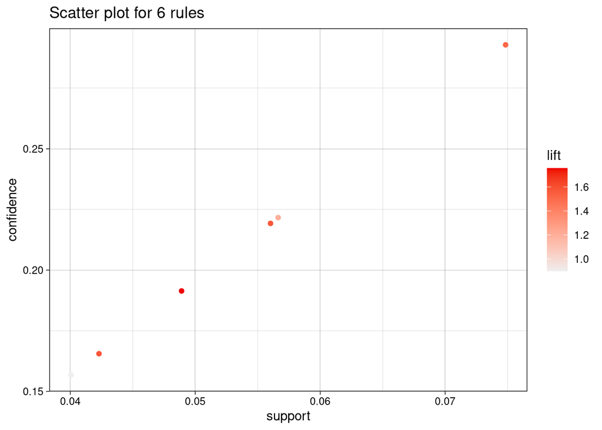

```r
plot(rules)
```

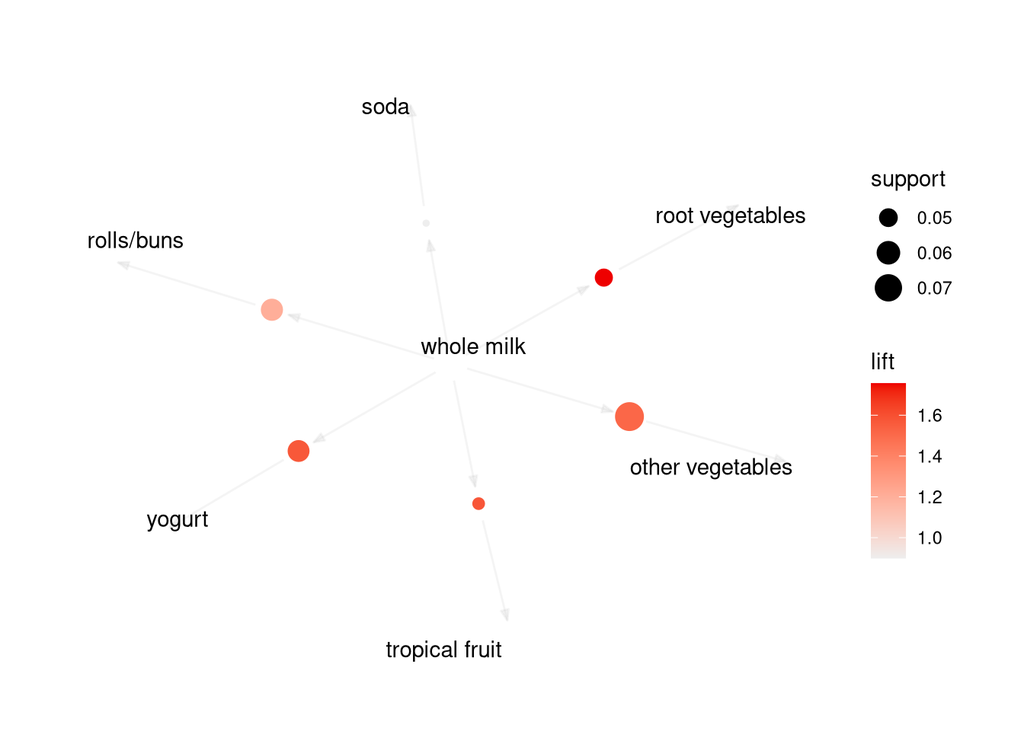

```r
plot(rules,method = "graph")
```

### **Ejercicio**

Vamos a familiarizarnos con la técnica de reglas de asociación usando un dataset “clásico”. Usaremos los datos del Tinanic `help("Titanic")`, que tenemos preparados en `datos/titanic_raw.csv`.

Usar dicha técnica para estudiar qué características tenian los supervivientes (lado de derecho `rhs`).